# Respiratory Virus Situation Report (AZ, NM, UT)

#### **COVID-19**

- The **National** epidemic trend is **not changing**.
  - The weekly percentage of ED visits diagnosed with COVID-19 is **very low**.
  - Probability epidemic is growing: **56.23%** (not changing).
- **Utah:** The epidemic trend is **not estimated**.
  - The weekly percentage of ED visits diagnosed with COVID-19 is **very low**.
  - Probability epidemic is growing: **NA%** (not estimated).
- **Arizona:** The epidemic trend is **not changing**.
  - The weekly percentage of ED visits diagnosed with COVID-19 is **very low**.
  - Probability epidemic is growing: **57.03%** (not changing).
- **New Mexico:** The epidemic trend is **growing**.
  - The weekly percentage of ED visits diagnosed with COVID-19 is **very low**.
  - Probability epidemic is growing: **95.93%** (growing).

#### **Influenza**

- The **National** epidemic trend is **growing**.
  - The weekly percentage of ED visits diagnosed with Influenza is **low**.
  - Probability epidemic is growing: **99.80%** (growing).
- **Utah:** The epidemic trend is **not estimated**.
  - The weekly percentage of ED visits diagnosed with Influenza is **low**.
  - Probability epidemic is growing: **NA%** (not estimated).
- **Arizona:** The epidemic trend is **growing**.
  - The weekly percentage of ED visits diagnosed with Influenza is **very low**.
  - Probability epidemic is growing: **99.80%** (growing).
- **New Mexico:** The epidemic trend is **growing**.
  - The weekly percentage of ED visits diagnosed with Influenza is **very low**.
  - Probability epidemic is growing: **91.45%** (growing).

#### **RSV**

- No state-level or national estimates are estimated for RSV this week.
  - Probability epidemic is growing: **NA%** (not estimated).

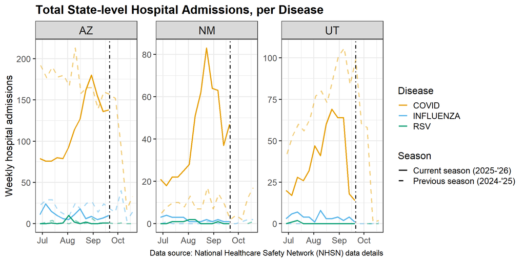

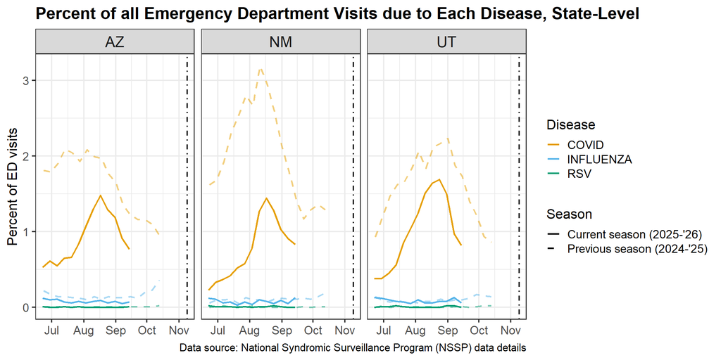

**Current Situation (latest available week)**

Forecast (Sunday) reference date: **2025-09-27**

| State | Virus | Latest Hosp Admissions (wk) | Latest ED % of visits |
| --- | --- | --- | --- |
| Arizona | COVID | 138 | 0.8% |
| Arizona | INFLUENZA | 10 | 0.1% |
| Arizona | RSV | 1 | 0.0% |
| New Mexico | COVID | 47 | 0.8% |
| New Mexico | INFLUENZA | 1 | 0.1% |
| New Mexico | RSV | 0 | 0.0% |
| Utah | COVID | 14 | 0.8% |
| Utah | INFLUENZA | 1 | 0.1% |
| Utah | RSV | 0 | 0.0% |

Latest available hospitalization data from: 2025-09-20; latest available ED data from: 2025-09-14

#### This report describes recent state-level trends in respiratory virus activity in Arizona, New Mexico, and Utah. It presents data on three respiratory viral diseases: COVID-19, influenza (flu), and respiratory syncytial virus (RSV). Trends in emergency department visits are based on [National Syndromic Surveillance Program (NSSP)](https://www.cdc.gov/nssp/php/about/index.html) data and provide estimates of how much symptomatic illness each virus is causing. Hospitalization trends are drawn from [National Healthcare Safety Network (NHSN)](https://www.cdc.gov/nhsn/about-nhsn/index.html) data and estimate the burden of severe disease and impact on the healthcare system caused by each virus.